# TMDB_FinalAnalysis

import all the libraries that are needed:

```r
library(caret)
library(cluster)
library(flexclust)
library(xgboost)
```

Read in the cleaned data sets:

```r
train_cluster = read.csv("train_clean2.csv")
test_cluster = read.csv("test_clean2.csv")
```

# final model:

After all the experiments with random forest, xgboost, xgboost with clustering first.etc, we found that xgboost with dummy variables give us the best test rmsle result. So we will do xgboost as our final model.

Check the dataframe first and drop some columns that we won’t use in clustering: We will drop columns that are texts, scaled data, and revenue, but keep logged revenue.

```r
head(train_cluster)
```

[output not shown]

[output cut: 153 more lines]

```r
drop_var3=c("X.1","X","id","original_title","overview","tagline","title","Keywords","revenue", "release_date","budget","budget2","popularity2","runtime2","numberOfGenres2","numberOfcasts2","numberOfcrews2","numberOfcompanies2","numberOflang2","numberOfcoun2","revenue2","mean1")
drop_var4=c("X.1","X","original_title","overview","tagline","title","Keywords","revenue", "release_date","budget","budget2","popularity2","runtime2","numberOfGenres2","numberOfcasts2","numberOfcrews2","numberOfcompanies2","numberOflang2","numberOfcoun2","revenue2","mean1")
train_cluster[,drop_var3]<-list(NULL)
test_cluster[,drop_var4]<-list(NULL)
head(train_cluster)
```

```
##   belongs_to_collection original_language popularity month year runtime
## 1                     1                en   6.575393     2 2015      93
## 2                     1                en   8.248895     8 2004     113
## 3                     0                en  64.299990    10 2014     105
## 4                     0                hi   3.174936     3 2012     122
## 5                     0                ko   1.148070     2 2009     118
## 6                     0                en   0.743274     8 1987      83
##   week_day numberOfGenres Action Adventure Animation Comedy Crime
## 1   Friday              1      0         0         0      1     0
## 2   Friday              4      0         0         0      1     0
## 3   Friday              1      0         0         0      0     0
## 4   Friday              2      0         0         0      0     0
## 5 Thursday              2      1         0         0      0     0
## 6 Thursday              3      0         1         1      0     0
##   Documentary Drama Family Fantasy Foreign History Horror Music Mystery
```

[output cut: 97 more lines]

We have categorical variables such as original_language, week_day and month, which are not accepable for xgboost. We will dummy them:

```r
train_cluster$month <- as.factor(train_cluster$month) #month should be a categorical variable
dmy <- dummyVars(" ~ original_language + week_day+month", data = train_cluster, fullRank=T)
dummy_df_train <- data.frame(predict(dmy, newdata = train_cluster))
train_cluster <- cbind(train_cluster,dummy_df_train) #combine dummies in the data set
drop <- c('original_language', 'week_day','month')
# # our train data have more dummy levels:
# [1] "original_language.fa"
# [1] "original_language.mr"
# [1] "original_language.nb"
# [1] "original_language.vi"
drop <- c(drop, "original_language.fa", "original_language.mr", "original_language.nb","original_language.vi")
train_cluster[,drop] <-list(NULL)

#do the same for test data
test_cluster$month <- as.factor(test_cluster$month) #month should be a categorical variable
dmy <- dummyVars(" ~ original_language + week_day+month", data = test_cluster, fullRank=T)
dummy_df_test <- data.frame(predict(dmy, newdata = test_cluster))
test_cluster <- cbind(test_cluster,dummy_df_test)
drop <- c('original_language', 'week_day','month')
# # our test dataset have more levels. we will drop:
# [1] "original_language.bm"
# [1] "original_language.ca"
# [1] "original_language.is"
# [1] "original_language.ka"
# [1] "original_language.kn"
# [1] "original_language.th"
# [1] "original_language.xx"
drop <- c(drop,"original_language.bm","original_language.ca","original_language.is","original_language.ka", "original_language.kn",
          "original_language.th","original_language.xx" )
test_cluster[,drop] <-list(NULL)
```

Split the train data into train and validation data sets:

```r
set.seed(617)
split = sample(1:nrow(train_cluster),size = 0.7*nrow(train_cluster))
train_model = train_cluster[split,]
validation_model = train_cluster[-split,]
```

Save the log.revenue label separetly and remove it from the dataset:

```r
train_modelLabel = train_model$log.revenue
validation_modellLabel = validation_model$log.revenue

train_model$log.revenue = NULL
validation_model$log.revenue=NULL
```

xgboost model:

```r
  xgb_train=as.matrix(train_model)
  params = list(
  eta = 0.01,
  max_depth = 50,
  min_child_weight = 7,
  colsample_bytree = 1)
  set.seed(123)

  xgb.fit.final = xgboost(
    params = params,
    data = xgb_train,
    label = train_modelLabel,
    nrounds = 400,
    subsample=0.55,
    objective = "reg:linear",
    print_every_n = 10)
  # for prediction
  xgb_scoring=as.matrix(validation_model)
  pred= predict(xgb.fit.final,newdata=xgb_scoring)
  rmsle = sqrt(mean((pred - validation_modellLabel)^2)); rmsle
```

```
## [1] 1.956101
```

```r
  testLabel=test_cluster$id
  test_cluster$id = NULL

  xgb_real_test=as.matrix(test_cluster)
  pred.test= predict(xgb.fit.final,newdata=xgb_real_test)
  pred.test_nolog=exp(pred.test)-1

  submission1= data.frame(id = testLabel, revenue = pred.test_nolog)
  write.csv(submission1, 'submissionNoCluster5.csv',row.names = F)
```

Our kaggle score is: 2.18789 our best score so far! This is our final analysis.

Let’s now check what’s the important variables in our model:

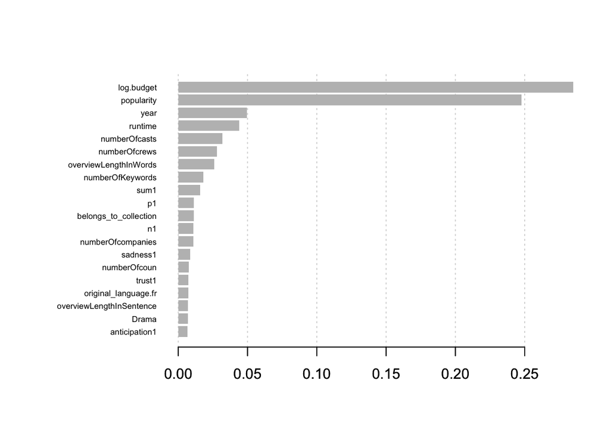

```r
importance_matrix<-xgb.importance(model =xgb.fit.final)
xgb.plot.importance(importance_matrix[1:20,])
```